# SCI6245: Clinical Bioinformatics

Module 1: Reproducible, Ethical and Effective Clinical Bioinformatics

Anais Chen Master of Bioinformatics Student Edith Cown University achen3@our.ecu.edu.au

Created: 25th February 2021 Last Updated: 08 March 2021

## Overview

Module 1 discusses conduct in clinical bioinformatics research practices, including reproducibility, ethics, and effective communication.

## Data Preparation

```r
#lists info sheets
excel_sheets("./data/surveys_data.xlsx")
```

```
## [1] "surveys"      "plot_info"    "species_info"
```

```r
#loading the main data
survey_data <- read_excel("./data/surveys_data.xlsx", sheet = 1)

#loading the plot info
plot_info <- read_excel("./data/surveys_data.xlsx", sheet = 2)

#load species info
species_info <- read_excel("./data/surveys_data.xlsx", sheet = 3)
```

First, I clean up the sex data and give new, easier to understand labels.

```r
#checks data structure, shows variable names and some code
str(survey_data)
```

```
## tibble [35,549 × 10] (S3: tbl_df/tbl/data.frame)
##  $ record_id      : num [1:35549] 1 2 3 4 5 6 7 8 9 10 ...
##  $ month          : num [1:35549] 7 7 7 7 7 7 7 7 7 7 ...
##  $ day            : num [1:35549] 16 16 16 16 16 16 16 16 16 16 ...
##  $ year           : num [1:35549] 1977 1977 1977 1977 1977 ...
##  $ plot_id        : num [1:35549] 2 3 2 7 3 1 2 1 1 6 ...
##  $ species_id     : chr [1:35549] "NL" "NL" "DM" "DM" ...
##  $ sex            : chr [1:35549] "M" "M" "F" "M" ...
##  $ hindfoot_length: num [1:35549] 32 33 37 36 35 14 NA 37 34 20 ...
##  $ weight         : num [1:35549] NA NA NA NA NA NA NA NA NA NA ...
##  $ date           : POSIXct[1:35549], format: "1977-07-16" "1977-07-16" ...
```

```r
#recodes sex to numeric
survey_data$sex <- ifelse(survey_data$sex=="M", 0, ifelse(survey_data$sex == "F", 1, "NA"))
survey_data$sex <- factor(survey_data$sex,
                          levels=c(0,1), labels=c("Male", "Female"))
```

Then I label the plots by the plot_type information.

```r
#explores the data structure
str(plot_info)
```

```
## tibble [24 × 2] (S3: tbl_df/tbl/data.frame)
##  $ plot_id  : num [1:24] 1 2 3 4 5 6 7 8 9 10 ...
##  $ plot_type: chr [1:24] "Spectab exclosure" "Control" "Long-term Krat Exclosure" "Control" ...
```

```r
#label plot_id by the plot_type info
survey_data$plot_id <- factor(survey_data$plot_id,
                              levels=plot_info$plot_id,
                              labels=plot_info$plot_type)
```

To complete the data labels, I create a new variable for species ID, combining the genus and the species variables, and append this to the survey data.

```r
#explores data structure
str(species_info)
```

```
## tibble [54 × 4] (S3: tbl_df/tbl/data.frame)
##  $ species_id: chr [1:54] "AB" "AH" "AS" "BA" ...
##  $ genus     : chr [1:54] "Amphispiza" "Ammospermophilus" "Ammodramus" "Baiomys" ...
##  $ species   : chr [1:54] "bilineata" "harrisi" "savannarum" "taylori" ...
##  $ taxa      : chr [1:54] "Bird" "Rodent" "Bird" "Rodent" ...
```

```r
#merges genus with species with a space between them
species_info$species_lab <- paste(species_info$genus, species_info$species, " ")

#checks first 10 rows
head(species_info[1:10,])
```

```
## # A tibble: 6 x 5
##   species_id genus          species        taxa   species_lab
##   <chr>      <chr>          <chr>          <chr>  <chr>
## 1 AB         Amphispiza     bilineata      Bird   "Amphispiza bilineata  "
## 2 AH         Ammospermophi… harrisi        Rodent "Ammospermophilus harrisi  "
## 3 AS         Ammodramus     savannarum     Bird   "Ammodramus savannarum  "
## 4 BA         Baiomys        taylori        Rodent "Baiomys taylori  "
## 5 CB         Campylorhynch… brunneicapill… Bird   "Campylorhynchus brunneicapil…
## 6 CM         Calamospiza    melanocorys    Bird   "Calamospiza melanocorys  "
```

```r
#removes lagging space
species_info$species_lab <- trimws(species_info$species_lab, which = "right")

#check first 10 rows
head(species_info[1:10,])
```

```
## # A tibble: 6 x 5
##   species_id genus           species         taxa  species_lab
##   <chr>      <chr>           <chr>           <chr> <chr>
## 1 AB         Amphispiza      bilineata       Bird  Amphispiza bilineata
## 2 AH         Ammospermophil… harrisi         Rode… Ammospermophilus harrisi
## 3 AS         Ammodramus      savannarum      Bird  Ammodramus savannarum
## 4 BA         Baiomys         taylori         Rode… Baiomys taylori
## 5 CB         Campylorhynchus brunneicapillus Bird  Campylorhynchus brunneicapil…
## 6 CM         Calamospiza     melanocorys     Bird  Calamospiza melanocorys
```

```r
#labels species_id values in survey_data
survey_data$species_id <- factor(survey_data$species_id,
                                 levels=species_info$species_id,
                                 labels=species_info$species_lab)

#checks main data
str(survey_data)
```

```
## tibble [35,549 × 10] (S3: tbl_df/tbl/data.frame)
##  $ record_id      : num [1:35549] 1 2 3 4 5 6 7 8 9 10 ...
##  $ month          : num [1:35549] 7 7 7 7 7 7 7 7 7 7 ...
##  $ day            : num [1:35549] 16 16 16 16 16 16 16 16 16 16 ...
##  $ year           : num [1:35549] 1977 1977 1977 1977 1977 ...
##  $ plot_id        : Factor w/ 5 levels "Spectab exclosure",..: 2 3 2 4 3 1 2 1 1 5 ...
##  $ species_id     : Factor w/ 54 levels "Amphispiza bilineata",..: 18 18 12 12 12 26 25 12 12 26 ...
##  $ sex            : Factor w/ 2 levels "Male","Female": 1 1 2 1 1 1 2 1 2 2 ...
##  $ hindfoot_length: num [1:35549] 32 33 37 36 35 14 NA 37 34 20 ...
##  $ weight         : num [1:35549] NA NA NA NA NA NA NA NA NA NA ...
##  $ date           : POSIXct[1:35549], format: "1977-07-16" "1977-07-16" ...
```

```r
#adds genus and taxa to survey_data
survey_data <- merge(survey_data, species_info[,c(2,4,5)],
                     by.x="species_id", by.y="species_lab")

#checks main data
str(survey_data)
```

```
## 'data.frame':    34786 obs. of  12 variables:
##  $ species_id     : Factor w/ 54 levels "Amphispiza bilineata",..: 3 3 2 2 2 2 2 2 2 2 ...
##  $ record_id      : num  18932 20588 27074 12824 22059 ...
##  $ month          : num  8 1 10 5 2 4 5 10 10 12 ...
##  $ day            : num  7 24 26 28 4 21 15 24 25 14 ...
##  $ year           : num  1991 1993 1997 1987 1995 ...
##  $ plot_id        : Factor w/ 5 levels "Spectab exclosure",..: 3 2 2 5 2 1 4 3 5 4 ...
##  $ sex            : Factor w/ 2 levels "Male","Female": NA NA NA NA NA NA NA NA NA NA ...
##  $ hindfoot_length: num  NA NA NA NA NA NA NA NA NA NA ...
##  $ weight         : num  NA NA NA NA NA NA NA NA NA NA ...
##  $ date           : POSIXct, format: "1991-08-07" "1993-01-24" ...
##  $ genus          : chr  "Ammodramus" "Ammodramus" "Ammospermophilus" "Ammospermophilus" ...
##  $ taxa           : chr  "Bird" "Bird" "Rodent" "Rodent" ...
```

On inspection of the data, many data points seem to be missing weight, hindfoot length and sex observations, so I flag the data with missing inputs and create a new survey data set that does not include them. I then check to make sure all the missing data points have been excluded.

```r
#creates new data set without missing data for sex or weight
survey_data$sexNA <- ifelse(is.na(survey_data$sex), 1, 0)  #creates number index for missing sex
survey_data$weightNA <- ifelse(is.na(survey_data$weight), 1, 0)
survey_data$anyNA <- ifelse(survey_data$sexNA==1 | survey_data$weightNA==1, 1, 0)  #creates number index for either missing

table(survey_data$sexNA, survey_data$anyNA)    #checks all sexNA are counted
```

```
##
##         0     1
##   0 32182   856
##   1     0  1748
```

```r
table(survey_data$weightNA, survey_data$anyNA) #checks all weightNA are counted
```

```
##
##         0     1
##   0 32182   101
##   1     0  2503
```

```r
table(survey_data$anyNA)
```

```
##
##     0     1
## 32182  2604
```

```r
survey_data2 <- survey_data[!survey_data$anyNA==1, ]    #creates new data excluding missing
dim(survey_data)
```

```
## [1] 34786    15
```

```r
str(survey_data2)
```

```
## 'data.frame':    32182 obs. of  15 variables:
##  $ species_id     : Factor w/ 54 levels "Amphispiza bilineata",..: 4 4 4 4 4 4 4 4 4 4 ...
##  $ record_id      : num  17486 19121 19249 17374 18252 ...
##  $ month          : num  4 10 11 4 1 3 12 11 3 5 ...
##  $ day            : num  26 10 13 24 12 7 15 14 14 25 ...
##  $ year           : num  1990 1991 1991 1990 1991 ...
##  $ plot_id        : Factor w/ 5 levels "Spectab exclosure",..: 3 2 3 1 3 3 3 3 3 3 ...
##  $ sex            : Factor w/ 2 levels "Male","Female": 1 1 1 1 2 2 2 2 2 2 ...
##  $ hindfoot_length: num  14 13 12 14 14 14 14 16 14 14 ...
##  $ weight         : num  7 6 8 7 9 9 8 9 8 10 ...
##  $ date           : POSIXct, format: "1990-04-26" "1991-10-10" ...
##  $ genus          : chr  "Baiomys" "Baiomys" "Baiomys" "Baiomys" ...
##  $ taxa           : chr  "Rodent" "Rodent" "Rodent" "Rodent" ...
##  $ sexNA          : num  0 0 0 0 0 0 0 0 0 0 ...
##  $ weightNA       : num  0 0 0 0 0 0 0 0 0 0 ...
##  $ anyNA          : num  0 0 0 0 0 0 0 0 0 0 ...
```

```r
head(survey_data2)
```

```
##          species_id record_id month day year                  plot_id    sex
## 743 Baiomys taylori     17486     4  26 1990 Long-term Krat Exclosure   Male
## 744 Baiomys taylori     19121    10  10 1991                  Control   Male
## 745 Baiomys taylori     19249    11  13 1991 Long-term Krat Exclosure   Male
## 746 Baiomys taylori     17374     4  24 1990        Spectab exclosure   Male
## 747 Baiomys taylori     18252     1  12 1991 Long-term Krat Exclosure Female
## 748 Baiomys taylori     19775     3   7 1992 Long-term Krat Exclosure Female
##     hindfoot_length weight       date   genus   taxa sexNA weightNA anyNA
## 743              14      7 1990-04-26 Baiomys Rodent     0        0     0
## 744              13      6 1991-10-10 Baiomys Rodent     0        0     0
## 745              12      8 1991-11-13 Baiomys Rodent     0        0     0
## 746              14      7 1990-04-24 Baiomys Rodent     0        0     0
## 747              14      9 1991-01-12 Baiomys Rodent     0        0     0
## 748              14      9 1992-03-07 Baiomys Rodent     0        0     0
```

```r
#creates a variable for year bins in intervals of 5
yearBreaks <- c(min(survey_data2$year), 1982, 1988, 1992, 1997, max(survey_data2$year))

#buckets the values into bins
survey_data2$yearBin <- cut(survey_data2$year,
                breaks = yearBreaks,
                include.lowest = TRUE,
                right = FALSE,
                labels = c("1977-1982", "1982-1987", "1987-1992", "1992-1997", "1997-2002"))

#checks year bin variable

table(survey_data2$yearBin)
```

```
##
## 1977-1982 1982-1987 1987-1992 1992-1997 1997-2002
##      4426      7941      5194      4786      9835
```

## Exploratory Analysis

### Preparation

```r
#creates total count variables
yearSumm <- survey_data2 %>%
  group_by(yearBin) %>%
  count() %>%
  as.data.frame()
yearSumm$p <- round(yearSumm$n/nrow(survey_data2)*100, 1) #calculates percentages

#creates sex count variables
sexSumm <- survey_data2 %>%
  select(yearBin, sex) %>%
  group_by(yearBin) %>%
  count(sex) %>%
  as.data.frame()
sexSumm$p <- c(round(sexSumm$n[1:2]/sum(sexSumm$n[1:2])*100, 1),
               round(sexSumm$n[3:4]/sum(sexSumm$n[3:4])*100, 1),
               round(sexSumm$n[5:6]/sum(sexSumm$n[5:6])*100, 1),
               round(sexSumm$n[7:8]/sum(sexSumm$n[7:8])*100, 1),
               round(sexSumm$n[9:10]/sum(sexSumm$n[9:10])*100, 1)) #calculates percentages

#creates mean variables
meanSumm <- survey_data2 %>%
  select(yearBin, hindfoot_length, weight) %>%
  group_by(yearBin) %>%
  summarise(across(.cols = everything(), ~mean(.,na.rm = TRUE))) %>%
  as.data.frame()

#creates sd variables
sdSumm <- survey_data2 %>%
  select(yearBin, hindfoot_length, weight) %>%
  group_by(yearBin) %>%
  summarise(across(.cols = everything(), ~sd(.,na.rm = TRUE))) %>%
  as.data.frame()

#numbers in plots by yearBin
plotSumm <- survey_data2 %>%
  select(yearBin, plot_id) %>%
  group_by(yearBin) %>%
  count(plot_id) %>%
  as.data.frame()
 #calculates plot percentages
plotSumm$p <- c(round(plotSumm$n[1:5]/sum(plotSumm$n[1:5])*100, 1),
                round(plotSumm$n[6:10]/sum(plotSumm$n[6:10])*100, 1),
                round(plotSumm$n[11:15]/sum(plotSumm$n[11:15])*100, 1),
                round(plotSumm$n[16:20]/sum(plotSumm$n[16:20])*100, 1),
                round(plotSumm$n[21:25]/sum(plotSumm$n[21:25])*100, 1))
```

```r
#creates a dataframe with the desored formatting of the final table
t1 <- data.frame(vars = c(paste0("**Total Count** (n) ","*(%)*"),
                          paste0("**Sex** (n) ","*(%)*"),
                          "*Male", "Female",
                          paste0("**Hindfoot Length** (mm) ","mean *(SD)*"),
                          paste0("**Weight** (g) ","mean *(SD)"),
                          paste0("**Plot Information** (n) ","*(%)*"),
                          "*Spectab Exclosure*", "*Control*", "*Rodent Exclosure*",
                          "*Long-term Krat Exclosure*", "*Short-term Krat Exclosure*"),
#column for 1977-1982
                 bin1 = c(paste0(yearSumm$n[1], " (", yearSumm$p[1], "%)"), "",
                          paste0(sexSumm$n[1:2], " (", sexSumm$p[1:2], "%)"),
                          paste0(round(meanSumm$hindfoot_length[1], 2), " (",
                                 round(sdSumm$hindfoot_length[1], 2), ")"),
                          paste0(round(meanSumm$weight[1], 2), " (",
                                 round(sdSumm$weight[1], 2), ")"), "",
                          paste0(plotSumm$n[1:5], " (", plotSumm$p[1:5], ")")),
#column for 1982-1987
                 bin2 = c(paste0(yearSumm$n[2], " (", yearSumm$p[2], "%)"), "",
                          paste0(sexSumm$n[3:4], " (", sexSumm$p[3:4], "%)"),
                          paste0(round(meanSumm$hindfoot_length[2], 2), " (",
                                 round(sdSumm$hindfoot_length[2], 2), ")"),
                          paste0(round(meanSumm$weight[2], 2), " (",
                                 round(sdSumm$weight[2], 2), ")"), "",
                          paste0(plotSumm$n[6:10], " (", plotSumm$p[6:10], ")")),
#column for 1987-1992
                 bin3 = c(paste0(yearSumm$n[3], " (", yearSumm$p[3], "%)"), "",
                          paste0(sexSumm$n[5:6], " (", sexSumm$p[5:6], "%)"),
                          paste0(round(meanSumm$hindfoot_length[3], 2), " (",
                                 round(sdSumm$hindfoot_length[3], 2), ")"),
                          paste0(round(meanSumm$weight[3], 2), " (",
                                 round(sdSumm$weight[3], 2), ")"), "",
                          paste0(plotSumm$n[11:15], " (", plotSumm$p[11:15], ")")),

#column for 1992-1997
                 bin4 = c(paste0(yearSumm$n[4], " (", yearSumm$p[4], "%)"), "",
                          paste0(sexSumm$n[7:8], " (", sexSumm$p[7:8], "%)"),
                          paste0(round(meanSumm$hindfoot_length[4], 2), " (",
                                 round(sdSumm$hindfoot_length[4], 2), ")"),
                          paste0(round(meanSumm$weight[4], 2), " (",
                                 round(sdSumm$weight[4], 2), ")"), "",
                          paste0(plotSumm$n[16:20], " (", plotSumm$p[16:20], ")")),
#column for 1992-1997
                 bin5 = c(paste0(yearSumm$n[5], " (", yearSumm$p[5], "%)"), "",
                          paste0(sexSumm$n[9:10], " (", sexSumm$p[9:10], "%)"),
                          paste0(round(meanSumm$hindfoot_length[5], 2), " (",
                                 round(sdSumm$hindfoot_length[5], 2), ")"),
                          paste0(round(meanSumm$weight[5], 2), " (",
                                 round(sdSumm$weight[5], 2), ")"), "",
                          paste0(plotSumm$n[21:25], " (", plotSumm$p[21:25], ")")),
stringsAsFactors = FALSE)
```

This checks the structure of the data frame before formatting into a table with kable.

```r
t1
```

```
##                                    vars          bin1          bin2
## 1             **Total Count** (n) *(%)*  4426 (13.8%)  7941 (24.7%)
## 2                     **Sex** (n) *(%)*
## 3                                 *Male  2296 (51.9%)  4231 (53.3%)
## 4                                Female  2130 (48.1%)  3710 (46.7%)
## 5  **Hindfoot Length** (mm) mean *(SD)* 35.71 (11.13) 31.76 (10.14)
## 6             **Weight** (g) mean *(SD) 63.66 (46.39) 51.79 (43.17)
## 7        **Plot Information** (n) *(%)*
## 8                   *Spectab Exclosure*    539 (12.2)    961 (12.1)
## 9                             *Control*   2094 (47.3)     3413 (43)
## 10                   *Rodent Exclosure*     384 (8.7)    894 (11.3)
## 11           *Long-term Krat Exclosure*    499 (11.3)     1268 (16)
## 12          *Short-term Krat Exclosure*    910 (20.6)   1405 (17.7)
##             bin3          bin4          bin5
## 1   5194 (16.1%)  4786 (14.9%)  9835 (30.6%)
## 2
## 3   2746 (52.9%)  2564 (53.6%)  5042 (51.3%)
## 4   2448 (47.1%)  2222 (46.4%)  4793 (48.7%)
## 5   27.02 (9.44)  27.07 (9.08)  27.03 (6.71)
## 6  37.15 (34.19) 31.03 (22.36) 34.22 (24.65)
## 7
## 8     609 (11.7)    534 (11.2)   1062 (10.8)
## 9    2317 (44.6)   2276 (47.6)   4511 (45.9)
## 10    763 (14.7)    796 (16.6)   1839 (18.7)
## 11    820 (15.8)     463 (9.7)     747 (7.6)
## 12    685 (13.2)      717 (15)     1676 (17)
```

Then, I create summary plots of the data variables

```r
#removes any levels where species_id has no data points
survey_data2$species_id <- droplevels(survey_data2$species_id)
survey_data2$genus <- as.factor(survey_data2$genus)

#creates plot for samples collected each year by genus
p1 <- survey_data2 %>%
  select(year, genus) %>%
  group_by(year) %>%
  count(genus) %>%
  ggplot( aes(x=year, y=n, colour=genus)) +
  geom_line(size=1.2) +
  theme_bw() +
  theme(legend.position = "bottom",
        axis.text.x = element_text(angle = 90)) +
  xlab("Year") + ylab("Number of Samples Collected")

#creates a boxplot comparing the weight of the sex variable by plot_id
p2 <- ggplot(survey_data2, aes(x=as.factor(plot_id), y=weight, fill = as.factor(sex))) +
    geom_boxplot(size = 0.5,
                 alpha = 0.5) +
  theme_bw() +
  labs(y = "Weight (g)", x = "", fill = "Sex") + theme(legend.position = "none") +
coord_flip()

#creates a boxplot comparing the hindfoot length of the sex variable by plot_id
p3 <- ggplot(survey_data2, aes(x=as.factor(plot_id), y=hindfoot_length, fill = as.factor(sex))) +
    geom_boxplot(size = 0.5,
                 alpha = 0.5) +
  theme_bw() +
  labs(y = "Hindfoot Length (mm)", x = "", fill = "Sex") +
  theme(axis.title.y=element_blank(),
        axis.text.y=element_blank(),
        axis.ticks.y=element_blank()) +
coord_flip()

#creates plots for weight and length by genus for each plot
p4 <- ggplot(survey_data2, aes(x=hindfoot_length, y=weight, colour=as.factor(genus))) +
  geom_point(na.rm = TRUE, alpha=0.5) + theme_bw() +
  xlab("Hindfoot Length (mm)") + ylab("Weight (g)") +
  facet_grid(~ plot_id) +
  scale_colour_discrete(name = "Genus") + theme(legend.position = "none")

#creates plots of weight for each plot
p5 <- ggplot(survey_data2, aes(x = weight, fill = plot_id)) +
  geom_histogram( aes(y = ..density.. ), bins = 50, colour = "black", alpha = 0.5) +
  geom_density(size=1, alpha=0.4) +
  theme_bw() + facet_grid(~ plot_id) + theme(legend.position = "none") +
  xlab("Weight (g)") + ylab("Density")

#creates plots of hindfoot length for each plot
p6 <- ggplot(survey_data2, aes(x = hindfoot_length, fill = plot_id)) +
  geom_histogram( aes(y = ..density.. ), bins = 50, colour = "black", alpha = 0.5) +
  geom_density(size=1, alpha=0.4) +
  theme_bw() + facet_grid(~ plot_id) + theme(legend.position = "none") +
  xlab("Hindfoot Length (mm)") + ylab("Density")
```

### Summary Table

```r
#creates summary table with kable
kable(t1,
      caption = "**Table 1. Summary of study variables in 5 year intervals**", #table caption
      col.names = c("", "1977-1982", "1982-1987", "1987-1992", "1992-1997", "1997-2002"), #column titles, leaving blank space for first column
      align = "lccccc",
      type = "") %>%
  column_spec(1, width_min = "4cm", border_right = "2px solid black") %>%
  column_spec(c(2,3,4,5,6), width_min = "3cm", border_right = "1px solid #dddddd" ) %>%
  row_spec(0, bold=T, color="white", background="#666666") %>%
  kable_styling(bootstrap_options = c("striped", "hover"), full_width = FALSE) %>%
  add_indent(c(3,4,8:12)) %>%  # indent rows for measures with levels
  footnote(general = c("*% are within groups for all non-missing values*")) %>% # add footnote
  add_header_above(c(" " = 1, "Year" = 5), bold=T, color="white", background="#666666", include_empty = T)
```

|  | 1977-1982 | 1982-1987 | 1987-1992 | 1992-1997 | 1997-2002 |
| --- | --- | --- | --- | --- | --- |
| **Total Count** (n) *(%)* | 4426 (13.8%) | 7941 (24.7%) | 5194 (16.1%) | 4786 (14.9%) | 9835 (30.6%) |
| **Sex** (n) *(%)* |  |  |  |  |  |
| *Male | 2296 (51.9%) | 4231 (53.3%) | 2746 (52.9%) | 2564 (53.6%) | 5042 (51.3%) |
| Female | 2130 (48.1%) | 3710 (46.7%) | 2448 (47.1%) | 2222 (46.4%) | 4793 (48.7%) |
| **Hindfoot Length** (mm) mean *(SD)* | 35.71 (11.13) | 31.76 (10.14) | 27.02 (9.44) | 27.07 (9.08) | 27.03 (6.71) |
| **Weight** (g) mean *(SD) | 63.66 (46.39) | 51.79 (43.17) | 37.15 (34.19) | 31.03 (22.36) | 34.22 (24.65) |
| **Plot Information** (n) *(%)* |  |  |  |  |  |
| *Spectab Exclosure* | 539 (12.2) | 961 (12.1) | 609 (11.7) | 534 (11.2) | 1062 (10.8) |
| *Control* | 2094 (47.3) | 3413 (43) | 2317 (44.6) | 2276 (47.6) | 4511 (45.9) |
| *Rodent Exclosure* | 384 (8.7) | 894 (11.3) | 763 (14.7) | 796 (16.6) | 1839 (18.7) |
| *Long-term Krat Exclosure* | 499 (11.3) | 1268 (16) | 820 (15.8) | 463 (9.7) | 747 (7.6) |
| *Short-term Krat Exclosure* | 910 (20.6) | 1405 (17.7) | 685 (13.2) | 717 (15) | 1676 (17) |

Note:  
*% are within groups for all non-missing values*

### Data Visualisation

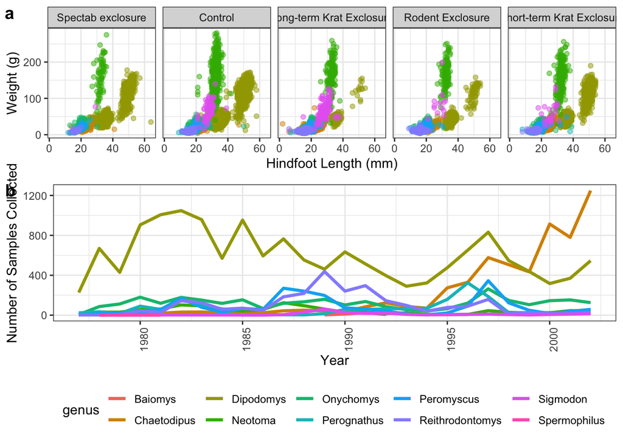

```r
ggarrange(
  p4, p1,
  labels = c("a", "b"),
  nrow = 2, heights = c(1,1.5)) #copied from Alyce's example
```

**Figure 1. Visualisations of Genera. a)** Hindfoot Length vs Weight, **b)** Samples Collected

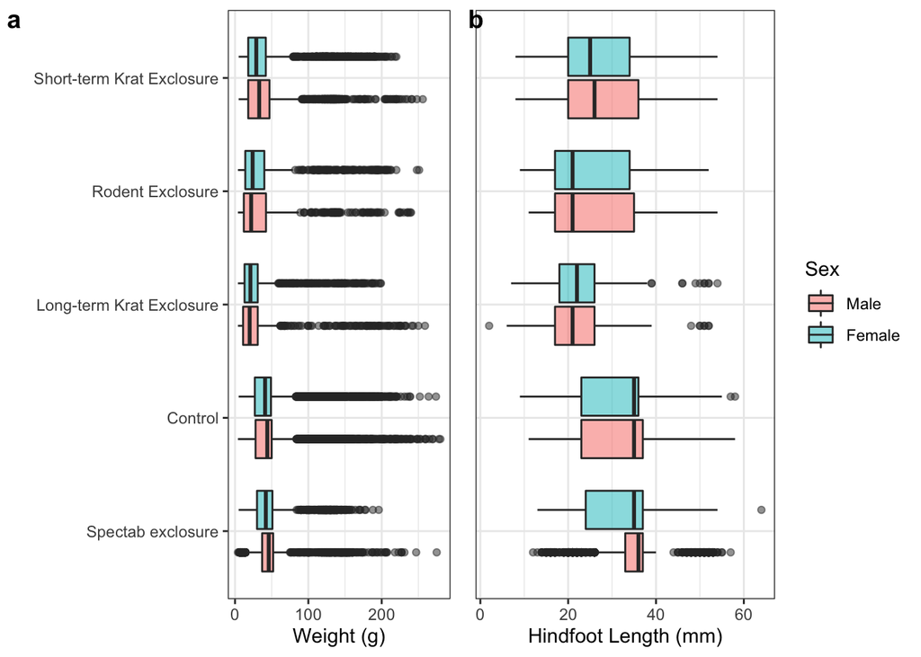

```r
ggarrange(
  p2, p3,
  labels = c("a", "b"),
  ncol = 2, nrow = 1)
```

**Figure 2. Distributions of Sex. a)** By Weight, **b)** By Hindfoot Length

```r
ggarrange(
  p5, p6,
  labels = c("a", "b"),
  ncol = 1, nrow = 2
)
```

[figure not shown]

**Figure 3. Distribution of Exclosure. a)** By Weight, **b)** By Hindfoot Length